# ADVERTISING ANALYSIS IN R

Chelagat Pauline Gechure

10/30/2020

# ADVERTISING ANALYSIS

## Research question

Identify which individuals are most likely to click on the ads of an online cryptography course on a blog of a Kenyan entrepreneur.

## Metric of success

Successful identification of an individuals characteristics

## Context

A Kenyan entrepreneur has created an online cryptography course and would want to advertise it on her blog. She currently targets audiences originating from various countries. In the past, she ran ads to advertise a related course on the same blog and collected data in the process. She would now like to employ your services as a Data Science Consultant to help her identify which individuals are most likely to click on her ads.

## Experimental design and appropriateness of available data.

Loading the data. Cleaning of the data: outliers, missing data, duplicates and anomalies. Univariate and bivariate EDA Recommendations

```r
#Loading the data
advertising <- read.csv("~/MORINGA DS CORE/UNSUPERVISED LEARNING/WEEK 12/advertising.csv")
View(advertising)

#Previweing the dataset
str(advertising)
```

```
## 'data.frame':    1000 obs. of  10 variables:
##  $ Daily.Time.Spent.on.Site: num  69 80.2 69.5 74.2 68.4 ...
##  $ Age                     : int  35 31 26 29 35 23 33 48 30 20 ...
##  $ Area.Income             : num  61834 68442 59786 54806 73890 ...
##  $ Daily.Internet.Usage    : num  256 194 236 246 226 ...
##  $ Ad.Topic.Line           : chr  "Cloned 5thgeneration orchestration" "Monitored national standardization" "Organic bottom-line service-desk" "Triple-buffered reciprocal time-frame" ...
##  $ City                    : chr  "Wrightburgh" "West Jodi" "Davidton" "West Terrifurt" ...
##  $ Male                    : int  0 1 0 1 0 1 0 1 1 1 ...
##  $ Country                 : chr  "Tunisia" "Nauru" "San Marino" "Italy" ...
##  $ Timestamp               : chr  "2016-03-27 00:53:11" "2016-04-04 01:39:02" "2016-03-13 20:35:42" "2016-01-10 02:31:19" ...
##  $ Clicked.on.Ad           : int  0 0 0 0 0 0 0 1 0 0 ...
```

```r
dim(advertising)
```

```
## [1] 1000   10
```

```r
head(advertising)
```

```
##   Daily.Time.Spent.on.Site Age Area.Income Daily.Internet.Usage
## 1                    68.95  35    61833.90               256.09
## 2                    80.23  31    68441.85               193.77
## 3                    69.47  26    59785.94               236.50
## 4                    74.15  29    54806.18               245.89
## 5                    68.37  35    73889.99               225.58
## 6                    59.99  23    59761.56               226.74
##                           Ad.Topic.Line           City Male    Country
## 1    Cloned 5thgeneration orchestration    Wrightburgh    0    Tunisia
## 2    Monitored national standardization      West Jodi    1      Nauru
## 3      Organic bottom-line service-desk       Davidton    0 San Marino
## 4 Triple-buffered reciprocal time-frame West Terrifurt    1      Italy
## 5         Robust logistical utilization   South Manuel    0    Iceland
## 6       Sharable client-driven software      Jamieberg    1     Norway
##             Timestamp Clicked.on.Ad
## 1 2016-03-27 00:53:11             0
## 2 2016-04-04 01:39:02             0
## 3 2016-03-13 20:35:42             0
## 4 2016-01-10 02:31:19             0
## 5 2016-06-03 03:36:18             0
## 6 2016-05-19 14:30:17             0
```

```r
class(advertising)
```

```
## [1] "data.frame"
```

```r
typeof(advertising)
```

```
## [1] "list"
```

```r
#Finding the lenght of the dataframe
length(advertising)
```

```
## [1] 10
```

## Cleaning the data

```r
##Cleaning the data
#Identifying the missing values
is.na(advertising)
```

[output not shown]

[output cut: 1987 more lines]

```r
# Finding the percentage of null values in the dataset
colSums(is.na(advertising))/length(advertising)*100
```

```
## Daily.Time.Spent.on.Site                      Age              Area.Income
##                        0                        0                        0
##     Daily.Internet.Usage            Ad.Topic.Line                     City
##                        0                        0                        0
##                     Male                  Country                Timestamp
##                        0                        0                        0
##            Clicked.on.Ad
##                        0
```

```r
#There are no missing values in the dataset.
```

There are no missing values in the dataset.

```r
##Checking and dealing with duplicates
duplicate_rows <- advertising[duplicated(advertising),]
duplicate_rows
```

```
##  [1] Daily.Time.Spent.on.Site Age                      Area.Income
##  [4] Daily.Internet.Usage     Ad.Topic.Line            City
##  [7] Male                     Country                  Timestamp
## [10] Clicked.on.Ad
## <0 rows> (or 0-length row.names)
```

There are no duplicate values in the dataset.

##Outliers

```r
##Checking and dealing with outliers

library(tidyverse)
```

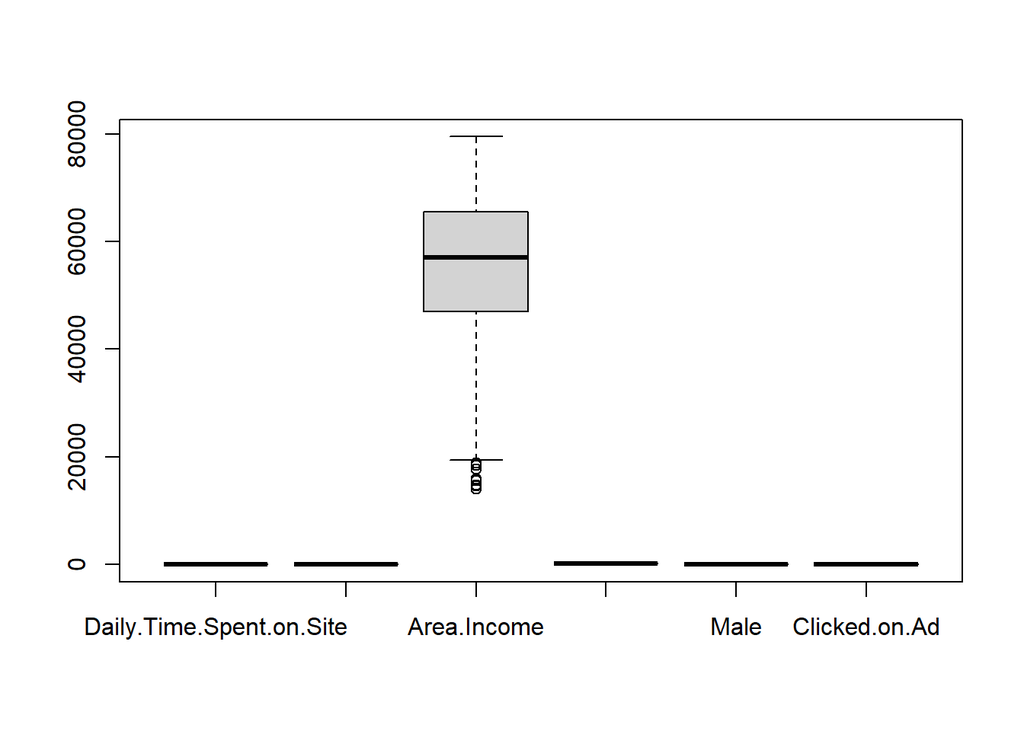

```r
outliers <- boxplot(advertising %>% select_if(is.numeric))
```

```r
outliers
```

```
## $stats
##        [,1] [,2]     [,3]    [,4] [,5] [,6]
## [1,] 32.600   19 19345.36 104.780    0  0.0
## [2,] 51.340   29 47012.58 138.790    0  0.0
## [3,] 68.215   35 57012.30 183.130    0  0.5
## [4,] 78.555   42 65479.35 218.795    1  1.0
## [5,] 91.430   61 79484.80 269.960    1  1.0
##
## $n
## [1] 1000 1000 1000 1000 1000 1000
##
## $conf
##          [,1]     [,2]     [,3]     [,4]        [,5]     [,6]
## [1,] 66.85523 34.35047 56089.63 179.1326 -0.04996399 0.450036
## [2,] 69.57477 35.64953 57934.97 187.1274  0.04996399 0.549964
##
## $out
## [1] 17709.98 18819.34 15598.29 15879.10 14548.06 13996.50 14775.50 18368.57
##
## $group
## [1] 3 3 3 3 3 3 3 3
##
## $names
## [1] "Daily.Time.Spent.on.Site" "Age"
## [3] "Area.Income"              "Daily.Internet.Usage"
## [5] "Male"                     "Clicked.on.Ad"
```

```r
#The column Area.income has outliers.

boxplot.stats(advertising$Area.income)$out
```

[output not shown]

```r
##Viewing the outliers
stat = boxplot.stats(advertising$Area.income)
stat
```

```
## $stats
## [1] NA NA NA NA NA
##
## $n
## [1] 0
##
## $conf
## [1] NA NA
##
## $out
## NULL
```

There are a few outliers in the Area Income column but they will not be remove as it is common for people to be of varying ages.

# UNIVARIATE SUMMARY

## 1. MEASURES OF CENTRAL TENDANCY

### MEAN

```r
##MEAN
#Finding the mean of daily time spent on site
daily.time.spent.mean <- mean(advertising$Daily.Time.Spent.on.Site)
daily.time.spent.mean
```

```
## [1] 65.0002
```

```r
#Finding the mean of age
age.mean <- mean(advertising$Age)
age.mean
```

```
## [1] 36.009
```

```r
#Finding the mean of area income
area.income.mean <- mean(advertising$Area.Income)
area.income.mean
```

```
## [1] 55000
```

```r
#Finding the mean of daily internt usage
daily.internet.mean <- mean(advertising$Daily.Internet.Usage)
daily.internet.mean
```

```
## [1] 180.0001
```

The mean dailt time spent on the site is 65. The mean age of the individual is 36 years. The mean area income is 55000 The mean daily internet usage is 180.

### MEDIAN

```r
##MEDIAN
#Finding the median of daily time spent on site
daily.time.spent.median <- median(advertising$Daily.Time.Spent.on.Site)
daily.time.spent.median
```

```
## [1] 68.215
```

```r
#Finding the median of age
age.median <- median(advertising$Age)
age.median
```

```
## [1] 35
```

```r
#Finding the median of area income
area.income.median <- median(advertising$Area.Income)
area.income.median
```

```
## [1] 57012.3
```

```r
#Finding the median of daily internt usage
daily.internet.median <- median(advertising$Daily.Internet.Usage)
daily.internet.median
```

```
## [1] 183.13
```

## MODE

```r
getmode <- function(v) {
   uniqv <- unique(v)
   uniqv[which.max(tabulate(match(v, uniqv)))]
}

# Calculating the mode using out getmode() function

#Finding the mode of daily time spent on site
daily.time.spent.mode<- getmode(advertising$Daily.Time.Spent.on.Site)
daily.time.spent.mode
```

```
## [1] 62.26
```

```r
#Finding the median of age
age.mode <- getmode(advertising$Age)
age.mode
```

```
## [1] 31
```

```r
#Finding the median of area income
area.income.mode <- getmode(advertising$Area.Income)
area.income.mode
```

```
## [1] 61833.9
```

```r
#Finding the median of daily internt usage
daily.internet.mode<- getmode(advertising$Daily.Internet.Usage)
daily.internet.mode
```

```
## [1] 167.22
```

```r
male.mode <- getmode(advertising$Male)
male.mode
```

```
## [1] 0
```

```r
clicks.mode <- getmode(advertising$Clicked.on.Ad)
clicks.mode
```

```
## [1] 0
```

```r
topics.mode <- getmode(advertising$Ad.Topic.Line)
topics.mode
```

```
## [1] "Cloned 5thgeneration orchestration"
```

```r
city.mode <- getmode(advertising$City)
city.mode
```

```
## [1] "Lisamouth"
```

```r
country.mode <- getmode(advertising$Country)
country.mode
```

```
## [1] "Czech Republic"
```

The mode daily time spent on the site is 62.26. The mode age of the individual is 31 years. The mode area income is 61833.9 The mode daily internet usage is 167.22 The most common topic is the Cloned 5th generation orchestration. The most common city is Losamouth. The most common country is Czech Republic.

## 2. MEASURES OF DISPERSION

### Min, 1st quantile, median, 3rd quantile and max

```r
#Finding the min, 1st quantilr, median, 3rd quantile and max of numeric columns.
advertising.summary <- summary(advertising)
advertising.summary
```

```
##  Daily.Time.Spent.on.Site      Age         Area.Income    Daily.Internet.Usage
##  Min.   :32.60            Min.   :19.00   Min.   :13996   Min.   :104.8
##  1st Qu.:51.36            1st Qu.:29.00   1st Qu.:47032   1st Qu.:138.8
##  Median :68.22            Median :35.00   Median :57012   Median :183.1
##  Mean   :65.00            Mean   :36.01   Mean   :55000   Mean   :180.0
##  3rd Qu.:78.55            3rd Qu.:42.00   3rd Qu.:65471   3rd Qu.:218.8
##  Max.   :91.43            Max.   :61.00   Max.   :79485   Max.   :270.0
##  Ad.Topic.Line          City                Male         Country
##  Length:1000        Length:1000        Min.   :0.000   Length:1000
##  Class :character   Class :character   1st Qu.:0.000   Class :character
##  Mode  :character   Mode  :character   Median :0.000   Mode  :character
##                                        Mean   :0.481
##                                        3rd Qu.:1.000
##                                        Max.   :1.000
##   Timestamp         Clicked.on.Ad
##  Length:1000        Min.   :0.0
##  Class :character   1st Qu.:0.0
##  Mode  :character   Median :0.5
##                     Mean   :0.5
##                     3rd Qu.:1.0
##                     Max.   :1.0
```

```r
#For each column
daily.time.summary <- summary(advertising$ Daily.Time.Spent.on.Site)
daily.time.summary
```

```
##    Min. 1st Qu.  Median    Mean 3rd Qu.    Max.
##   32.60   51.36   68.22   65.00   78.55   91.43
```

```r
age.summary <- summary(advertising$Age)
age.summary
```

```
##    Min. 1st Qu.  Median    Mean 3rd Qu.    Max.
##   19.00   29.00   35.00   36.01   42.00   61.00
```

```r
area.income.summary <- summary(advertising$Area.Income)
area.income.summary
```

```
##    Min. 1st Qu.  Median    Mean 3rd Qu.    Max.
##   13996   47032   57012   55000   65471   79485
```

```r
daily.internet.summary <- summary(advertising$ Daily.Internet.Usage)
daily.internet.summary
```

```
##    Min. 1st Qu.  Median    Mean 3rd Qu.    Max.
##   104.8   138.8   183.1   180.0   218.8   270.0
```

### Quantile

```r
#For each column
daily.time.quantile <- quantile(advertising$ Daily.Time.Spent.on.Site)
daily.time.quantile
```

```
##      0%     25%     50%     75%    100%
## 32.6000 51.3600 68.2150 78.5475 91.4300
```

```r
age.quantile <- quantile(advertising$Age)
age.quantile
```

```
##   0%  25%  50%  75% 100%
##   19   29   35   42   61
```

```r
area.income.quantile <- quantile(advertising$Area.Income)
area.income.quantile
```

```
##       0%      25%      50%      75%     100%
## 13996.50 47031.80 57012.30 65470.64 79484.80
```

```r
daily.internet.quantile <- quantile(advertising$ Daily.Internet.Usage)
daily.internet.quantile
```

```
##       0%      25%      50%      75%     100%
## 104.7800 138.8300 183.1300 218.7925 269.9600
```

Daily time spent on the site ranges between 32.6 - 91.43.. Age of the individual ranges between 19-61 . Area income ranges between 13996 - 79484 Daily internet usage ranges between 104.78-269.96.

### Variance

```r
#For each column
daily.time.var <- var(advertising$ Daily.Time.Spent.on.Site)
daily.time.var
```

```
## [1] 251.3371
```

```r
age.var <- var(advertising$Age)
age.var
```

```
## [1] 77.18611
```

```r
area.income.var <- var(advertising$Area.Income)
area.income.var
```

```
## [1] 179952406
```

```r
daily.internet.var <- var(advertising$ Daily.Internet.Usage)
daily.internet.var
```

```
## [1] 1927.415
```

The variance of daily time spent on the site is 251.3371. The variance age of the individual is 77.1861 years. The variance area income is 179952406 The varaince daily internet usage is 1927.415.

### Standard deviation

```r
#For each column
daily.time.sd <- sd(advertising$ Daily.Time.Spent.on.Site)
daily.time.sd
```

```
## [1] 15.85361
```

```r
age.sd <- sd(advertising$Age)
age.sd
```

```
## [1] 8.785562
```

```r
area.income.sd <- sd(advertising$Area.Income)
area.income.sd
```

```
## [1] 13414.63
```

```r
daily.internet.sd <- sd(advertising$ Daily.Internet.Usage)
daily.internet.sd
```

```
## [1] 43.90234
```

The standard deviation of daily time spent on the site is 15.85361. The standard deviation of age of the individual is 8.7855. The standard deviation of area income is 13414.63 The standard deviation daily internet usage is 43.9023

# 3. Graphical univariate

## Boxplots

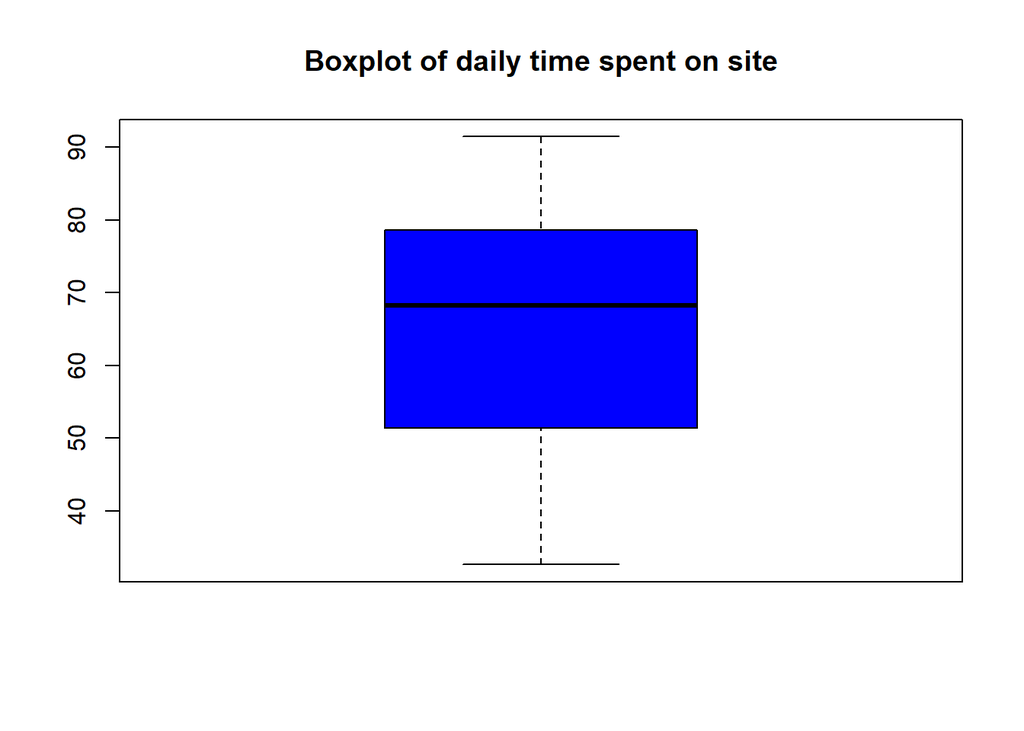

```r
# For each column
boxplot(advertising$ Daily.Time.Spent.on.Site, main = "Boxplot of daily time spent on site", col = "blue")
```

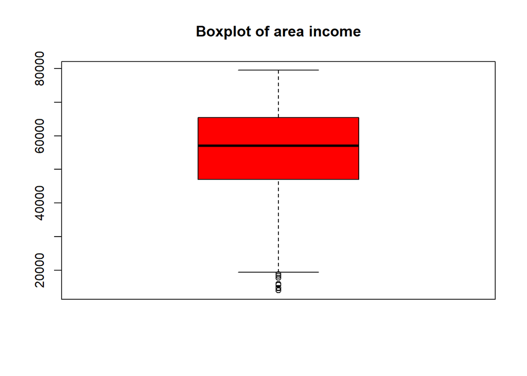

```r
boxplot(advertising$Area.Income, main = "Boxplot of area income", col = "red")
```

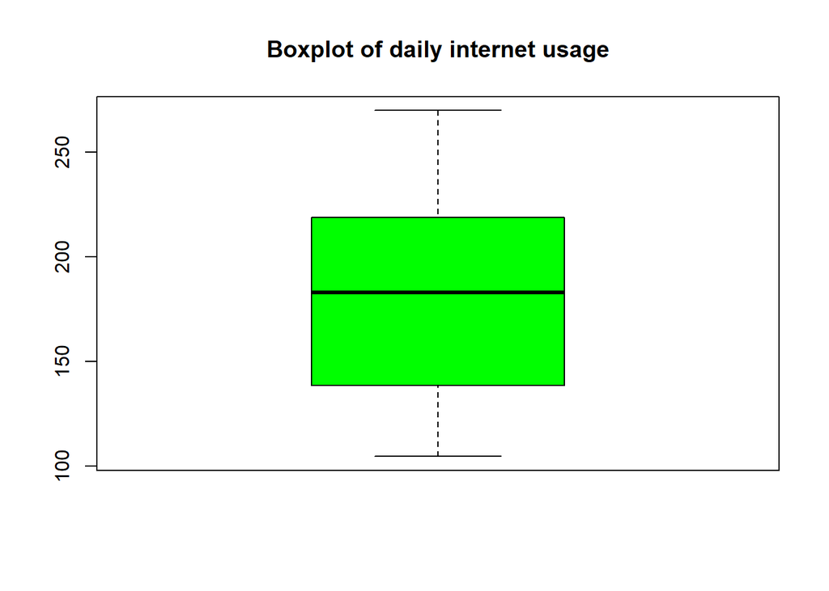

```r
boxplot(advertising$ Daily.Internet.Usage, main = "Boxplot of daily internet usage", col = "green")
```

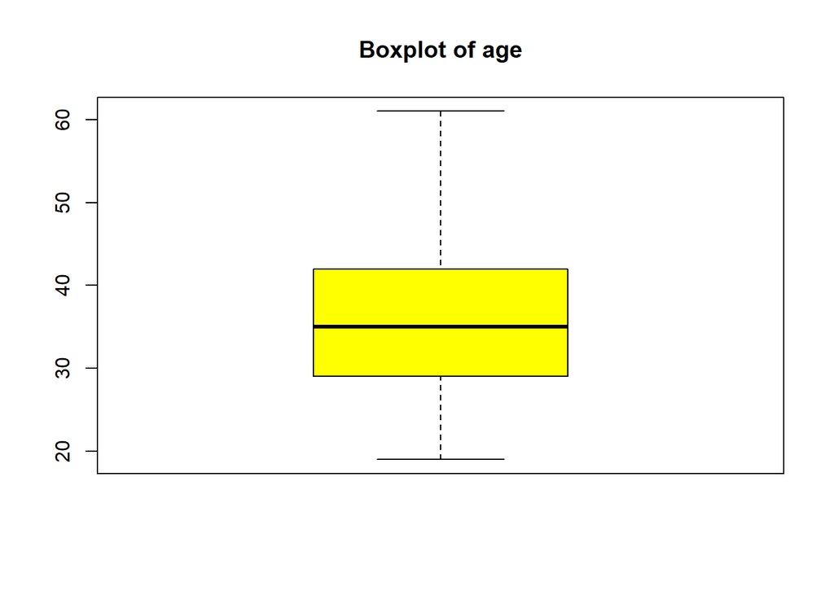

```r
boxplot(advertising$Age, main = "Boxplot of age", col = "yellow")
```

## Bar graphs

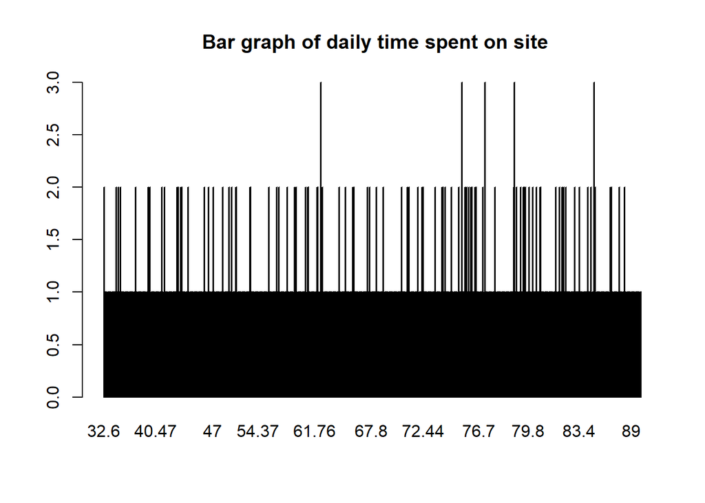

```r
#For each numeric column

daily.time.spent.frequency <- table(advertising$Daily.Time.Spent.on.Site)
barplot(daily.time.spent.frequency, main =" Bar graph of daily time spent on site", col =  "blue")
```

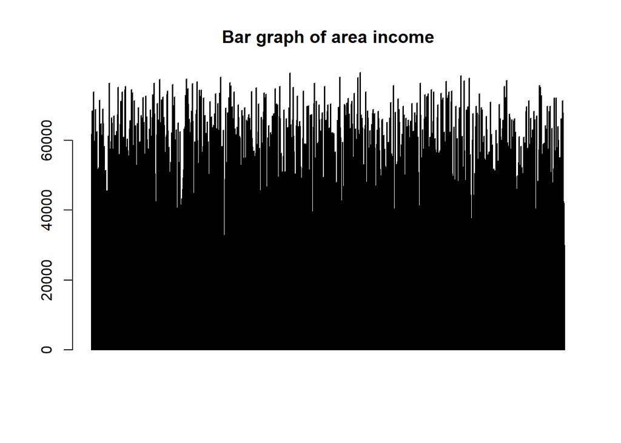

```r
area.income.frequency <- (advertising$Area.Income)
barplot(area.income.frequency, main = "Bar graph of area income", col = "red")
```

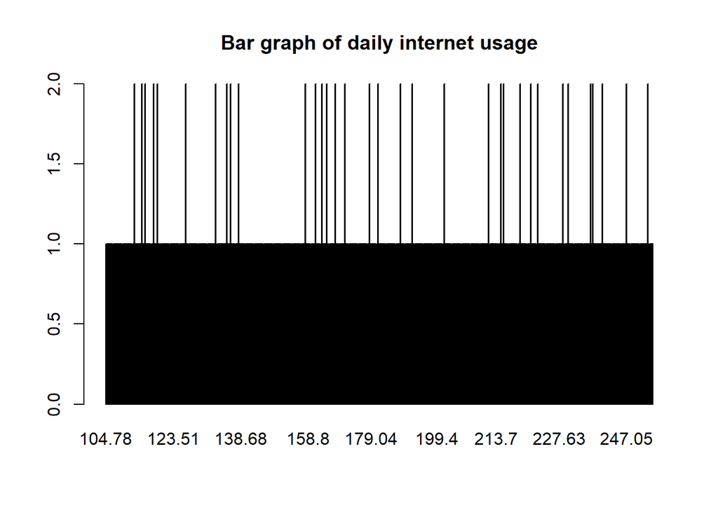

```r
daily.internet.frequency <- table(advertising$ Daily.Internet.Usage)
barplot(daily.internet.frequency, main = "Bar graph of daily internet usage", col = "green")
```

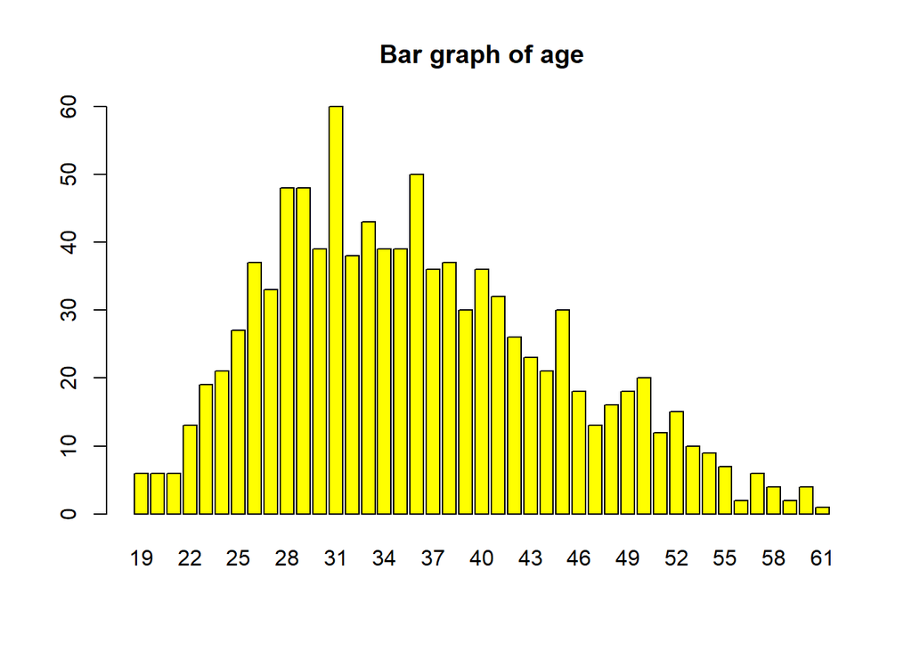

```r
age.frequency <- table(advertising$Age)
barplot(age.frequency, main = "Bar graph of age", col = "yellow")
```

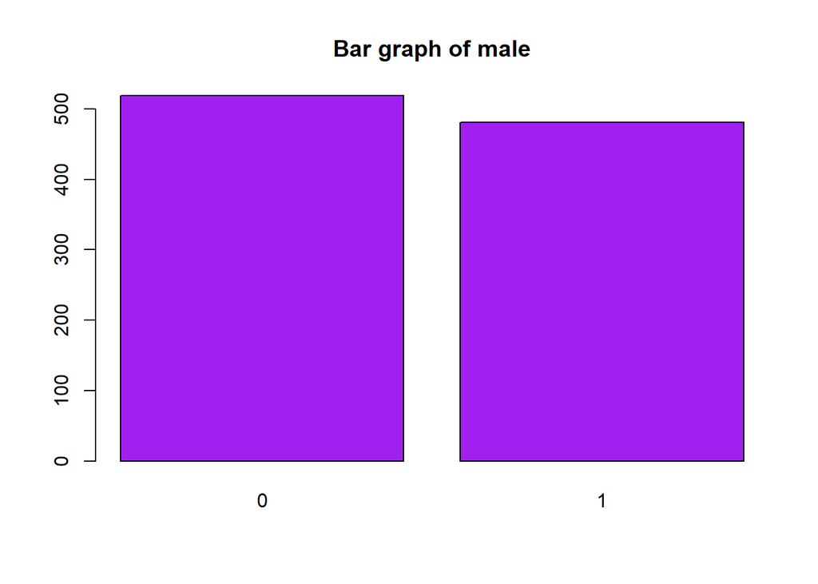

```r
male.frequency <- table(advertising$Male)
barplot(male.frequency, main="Bar graph of male", col = "purple")
```

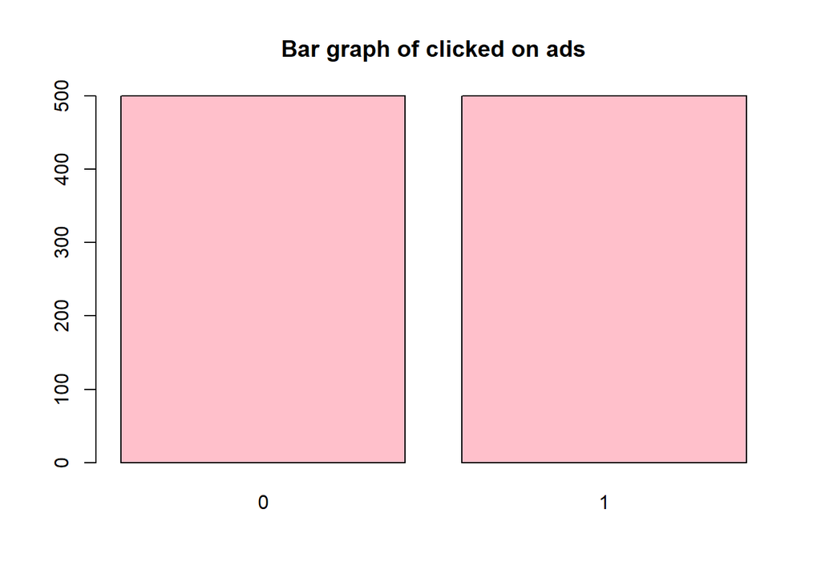

```r
clicked.on.frequency <- table(advertising$Clicked.on.Ad)
barplot(clicked.on.frequency, main="Bar graph of clicked on ads", col="pink")
```

The column age is slightly positively skewed to the right and has a normal kurtosis. ## Histograms

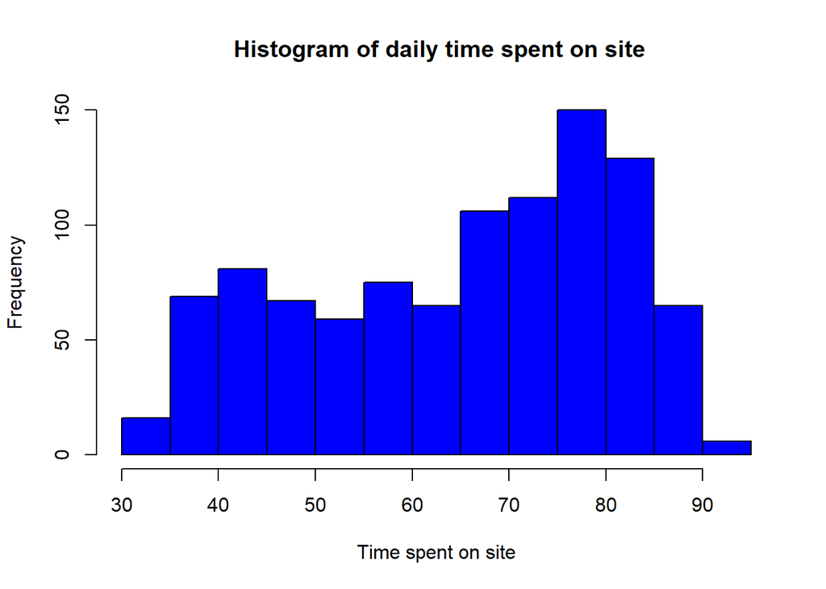

```r
#For each column
hist(advertising$Daily.Time.Spent.on.Site, main = " Histogram of daily time spent on site", xlab = "Time spent on site", col="blue")
```

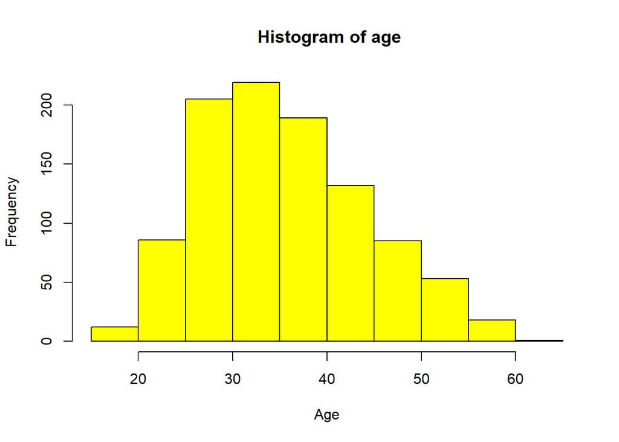

```r
hist(advertising$Age, main = " Histogram of age", xlab = "Age", col = " yellow")
```

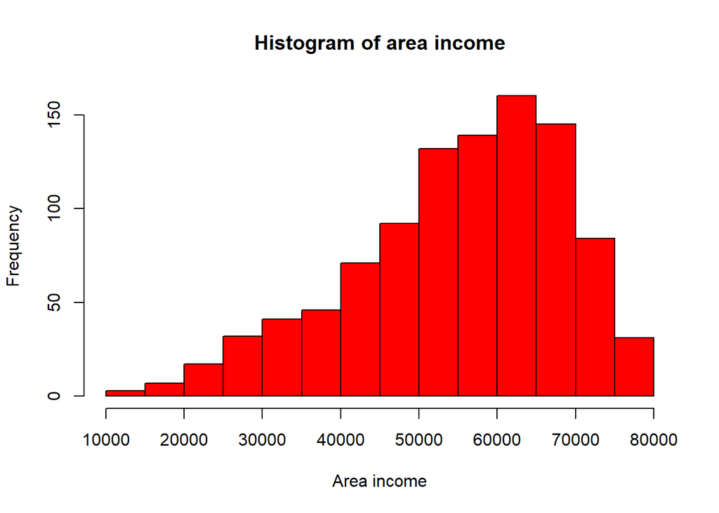

```r
hist(advertising$Area.Income, main = "Histogram of area income", xlab = "Area income", col = "red")
```

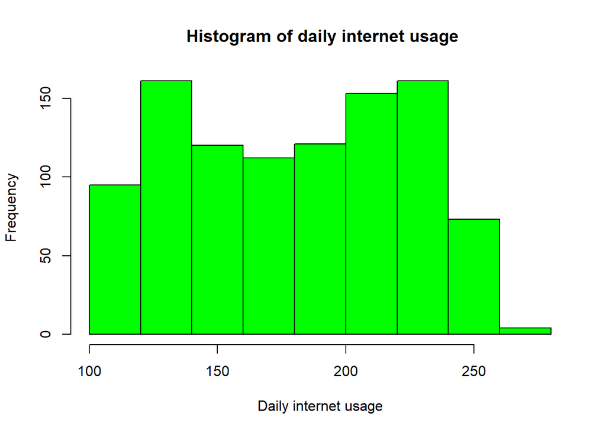

```r
hist(advertising$Daily.Internet.Usage, main = " Histogram of daily internet usage", xlab = "Daily internet usage", col ="green")
```

Daily time is negatively skewed and appears to be double peaked. Age column is positively skewed. Area income is negatively skewed and has a normal kurtosis. Daily internet usage is double peaked.

# 4. Bivariate and multivariate graphical analysis

## Bivariate summary

### Covariance

```r
# Assigning the columns to variables
site <- advertising$Daily.Time.Spent.on.Site
age <- advertising$Age
income <- advertising$Area.Income
internet <- advertising$Daily.Internet.Usage
male <-advertising$Male
clicks <- advertising$Clicked.on.Ad

# Using the cov() function to find the covariance
cov(site, age)
```

```
## [1] -46.17415
```

```r
cov(site, income)
```

```
## [1] 66130.81
```

```r
cov(site, internet)
```

```
## [1] 360.9919
```

```r
cov(site, male)
```

```
## [1] -0.1501864
```

```r
cov(site, clicks)
```

```
## [1] -5.933143
```

```r
cov(age,income)
```

```
## [1] -21520.93
```

```r
cov(age,internet)
```

```
## [1] -141.6348
```

```r
cov(age, male)
```

```
## [1] -0.09242142
```

```r
cov(age, clicks)
```

```
## [1] 2.164665
```

```r
cov(income, internet)
```

```
## [1] 198762.5
```

```r
cov(income, male)
```

```
## [1] 8.867509
```

```r
cov(income, clicks)
```

```
## [1] -3195.989
```

```r
cov(internet, male)
```

```
## [1] 0.6147667
```

```r
cov(internet, clicks)
```

```
## [1] -17.27409
```

```r
cov(male, clicks)
```

```
## [1] -0.00950951
```

The covariance of daily time spent on a site and clicks on ad is about -5.933143. It indicates a negative linear relationship between the two variables. The covariance of age and clicks on ad is about 2.164665. It indicates a positive linear relationship between the two variables. The covariance of area income and clicks on ad is about -3195.989 It indicates a large negative linear relationship between the two variables. The covariance of daily internet usage and clicks on ad is about -17.27409. It indicates a negative linear relationship between the two variables.

### Correlation

```r
# Using the cor() function to find the covariance
cor(site, age)
```

```
## [1] -0.3315133
```

```r
cor(site, income)
```

```
## [1] 0.3109544
```

```r
cor(site, internet)
```

```
## [1] 0.5186585
```

```r
cor(site, male)
```

```
## [1] -0.01895085
```

```r
cor(site, clicks)
```

```
## [1] -0.7481166
```

```r
cor(age,income)
```

```
## [1] -0.182605
```

```r
cor(age,internet)
```

```
## [1] -0.3672086
```

```r
cor(age, male)
```

```
## [1] -0.02104406
```

```r
cor(age, clicks)
```

```
## [1] 0.4925313
```

```r
cor(income, internet)
```

```
## [1] 0.3374955
```

```r
cor(income, male)
```

```
## [1] 0.001322359
```

```r
cor(income, clicks)
```

```
## [1] -0.4762546
```

```r
cor(internet, male)
```

```
## [1] 0.02801233
```

```r
cor(internet, clicks)
```

```
## [1] -0.7865392
```

```r
cor(male, clicks)
```

```
## [1] -0.03802747
```

The correlation of daily time spent on a site and clicks on ad is about -0.748. The variables are strongly negatively linearly related. The correlation of age and clicks on ad is 0.4925. The variables are positively linearly related. The correlation of area income and clicks on ad is about -0.4762.The variables are negatively linearly related. The correlation of daily internet usage and clicks is -0.7865.The variables are strongly negatively linearly related. The correlation of male and clicks is -0.038.The variables are weakly negatively linearly related.

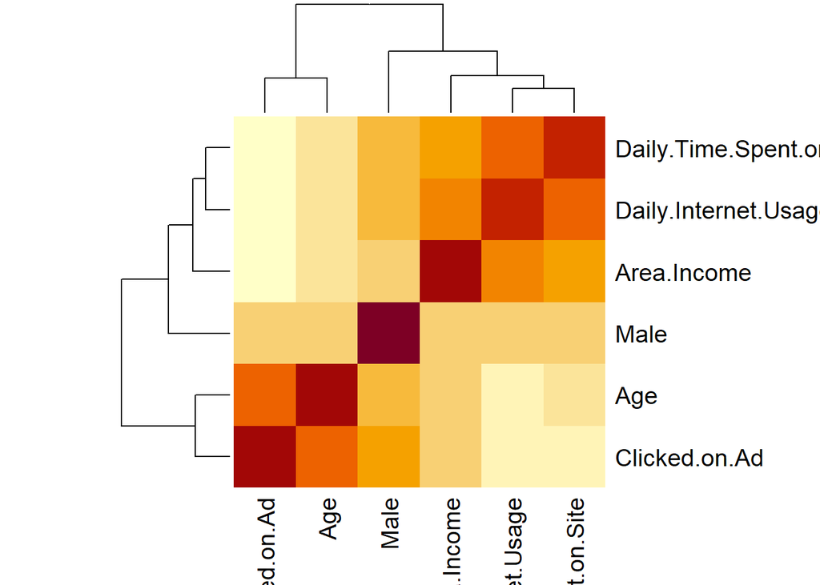

```r
## Creating a matrix
library(tidyverse)
matrix <- cor(advertising %>% select_if(is.numeric))

heatmap(matrix)
```

```r
#geom_tile(matrix)


##Method 1
library(reshape)
melted_cormat <- melt(matrix)
head(melted_cormat)
```

```
##                         X1                       X2       value
## 1 Daily.Time.Spent.on.Site Daily.Time.Spent.on.Site  1.00000000
## 2                      Age Daily.Time.Spent.on.Site -0.33151334
## 3              Area.Income Daily.Time.Spent.on.Site  0.31095441
## 4     Daily.Internet.Usage Daily.Time.Spent.on.Site  0.51865848
## 5                     Male Daily.Time.Spent.on.Site -0.01895085
## 6            Clicked.on.Ad Daily.Time.Spent.on.Site -0.74811656
```

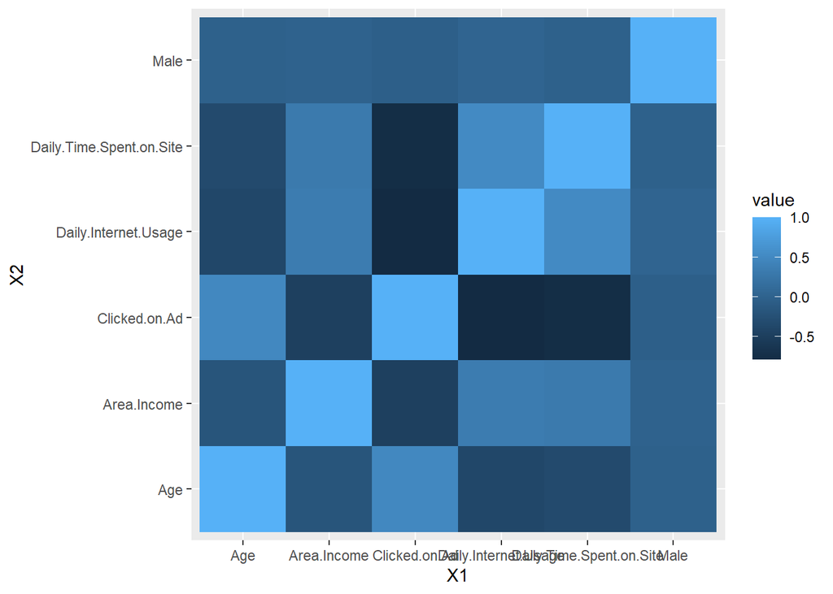

```r
library(ggplot2)
ggplot(data = melted_cormat, aes(x=X1, y=X2, fill=value)) +
  geom_tile()
```

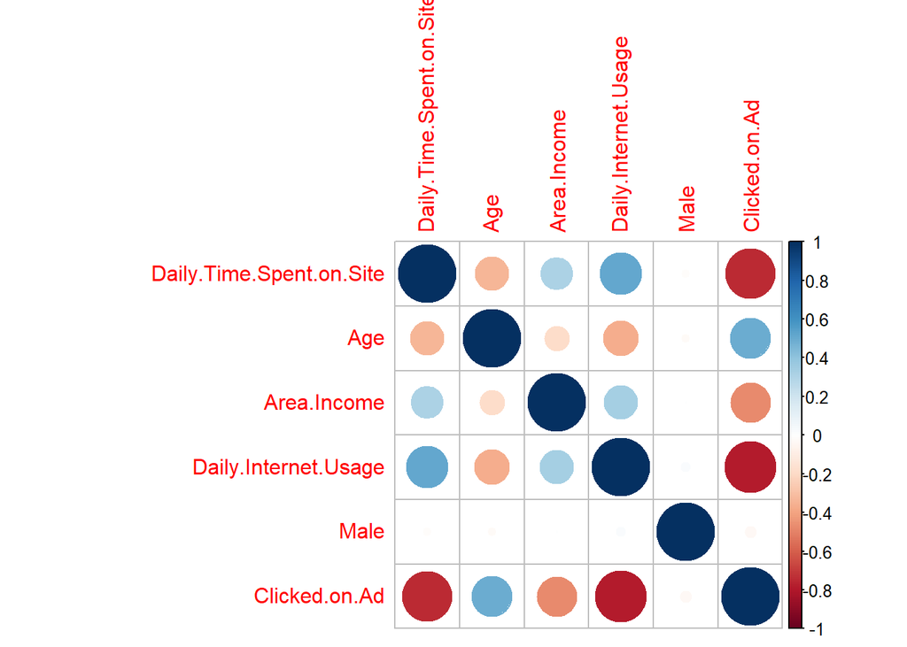

```r
##Mthod 2
corrplot::corrplot((matrix))
```

## Graphical techniques ### Scatterplots

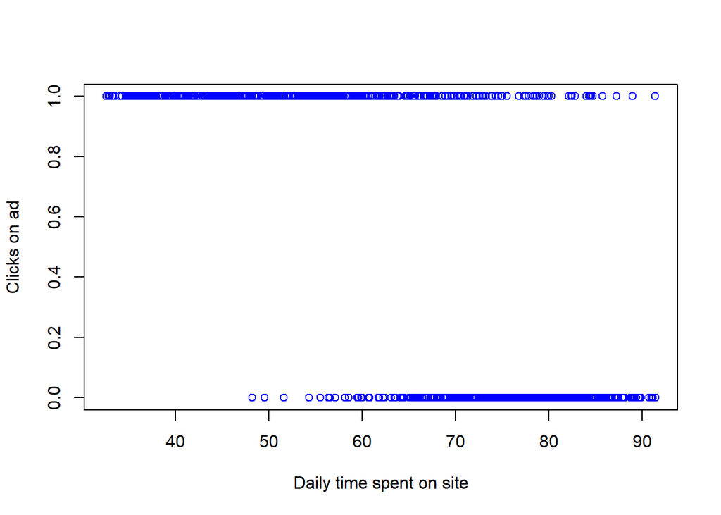

```r
# Creating the scatter plot of clicks and its relationship to other variables

plot(site, clicks, xlab="Daily time spent on site", ylab="Clicks on ad", col = "blue")
```

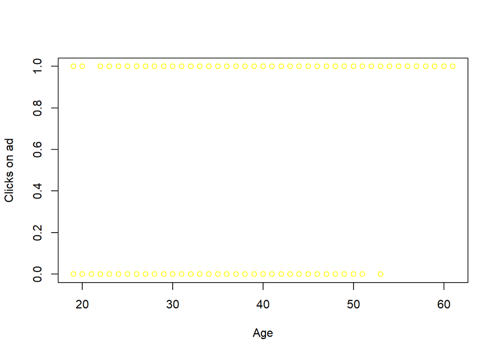

```r
plot(age, clicks, xlab="Age", ylab="Clicks on ad", col = "yellow")
```

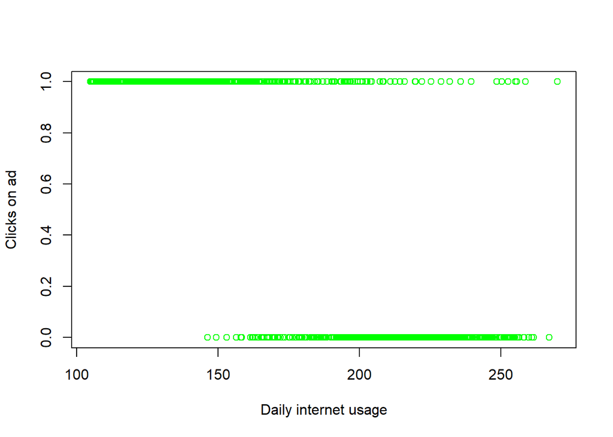

```r
plot(internet, clicks, xlab="Daily internet usage", ylab="Clicks on ad", col = "green")
```

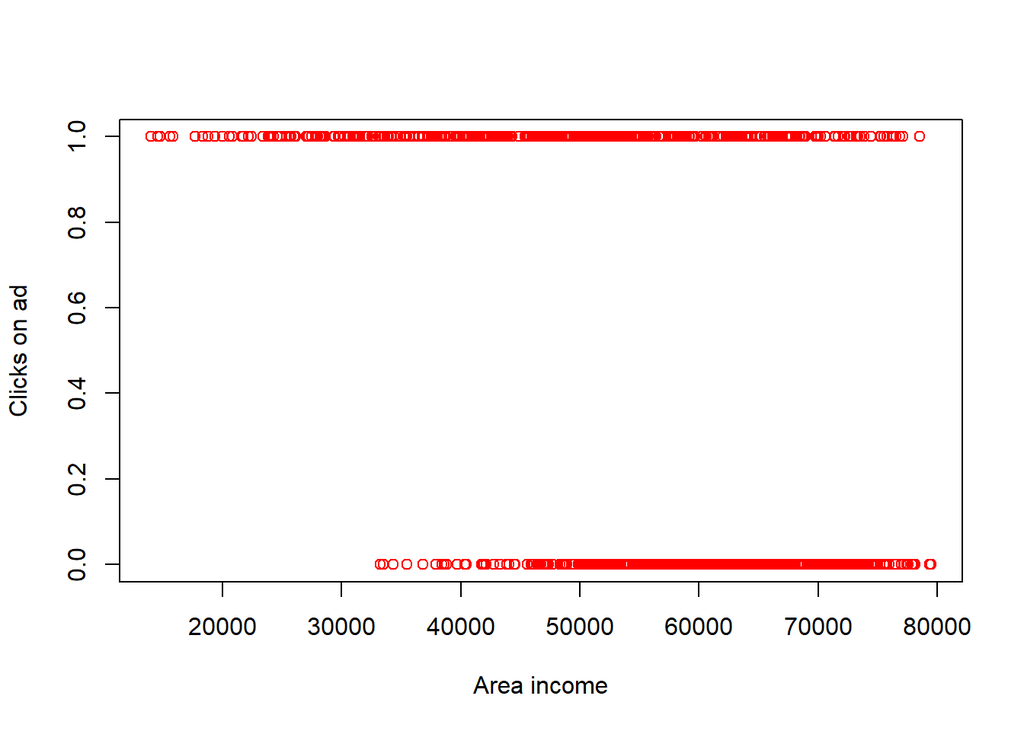

```r
plot(income, clicks, xlab="Area income", ylab="Clicks on ad", col = "red")
```

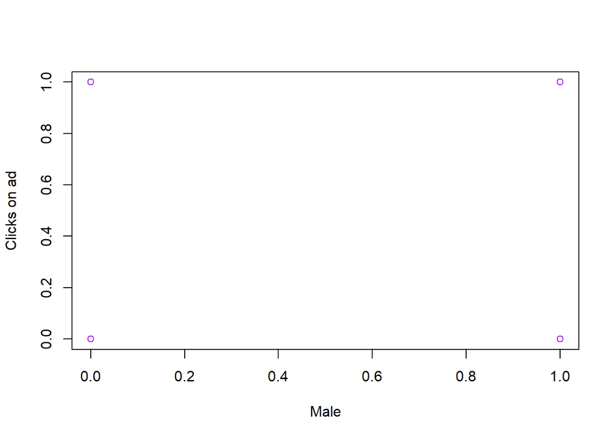

```r
plot(male, clicks, xlab="Male", ylab="Clicks on ad", col = "purple")
```

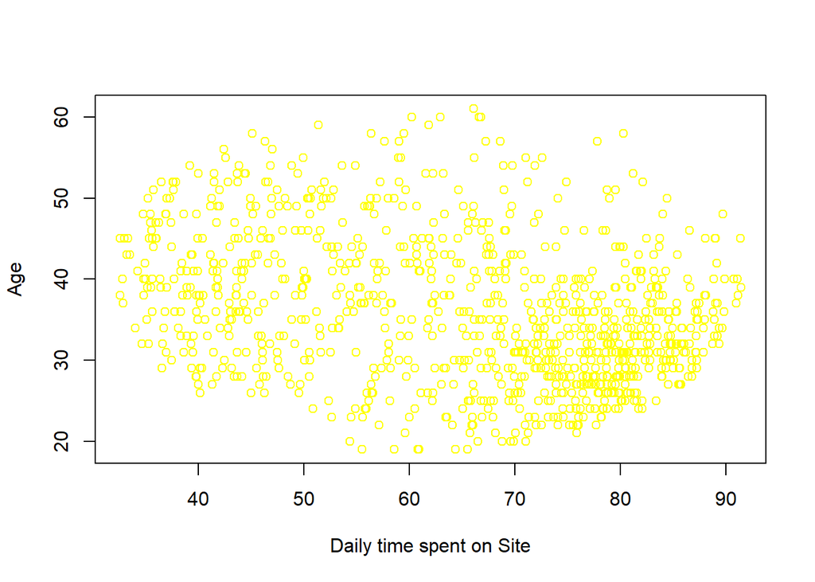

```r
# Creating the scatter plot of site and its relationship to other variables

plot(site, age, xlab="Daily time spent on Site", ylab="Age", col = "yellow")
```

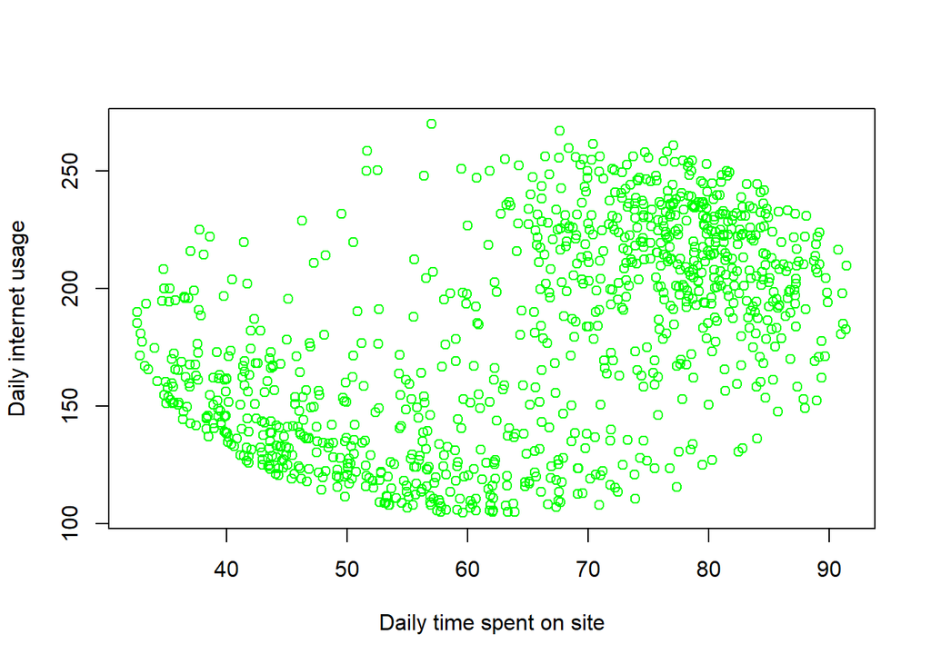

```r
plot(site, internet, xlab="Daily time spent on site", ylab="Daily internet usage", col = "green")
```

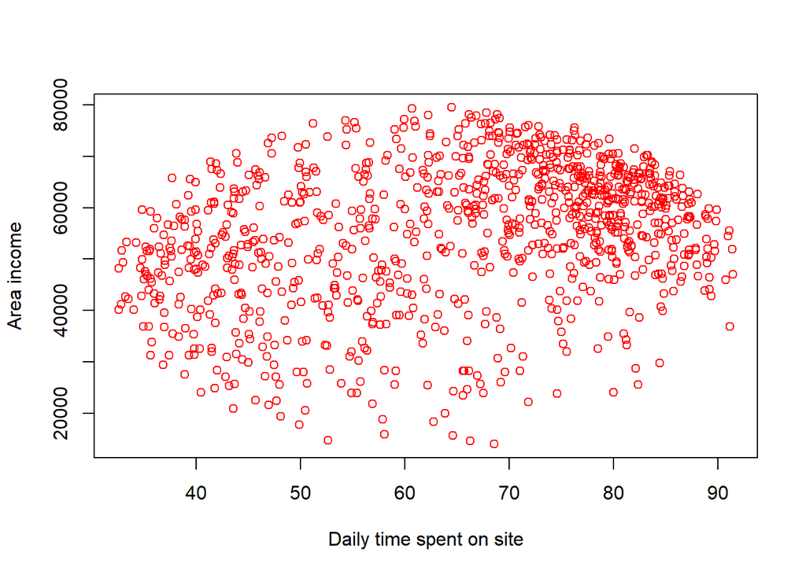

```r
plot(site, income, xlab="Daily time spent on site", ylab="Area income", col = "red")
```

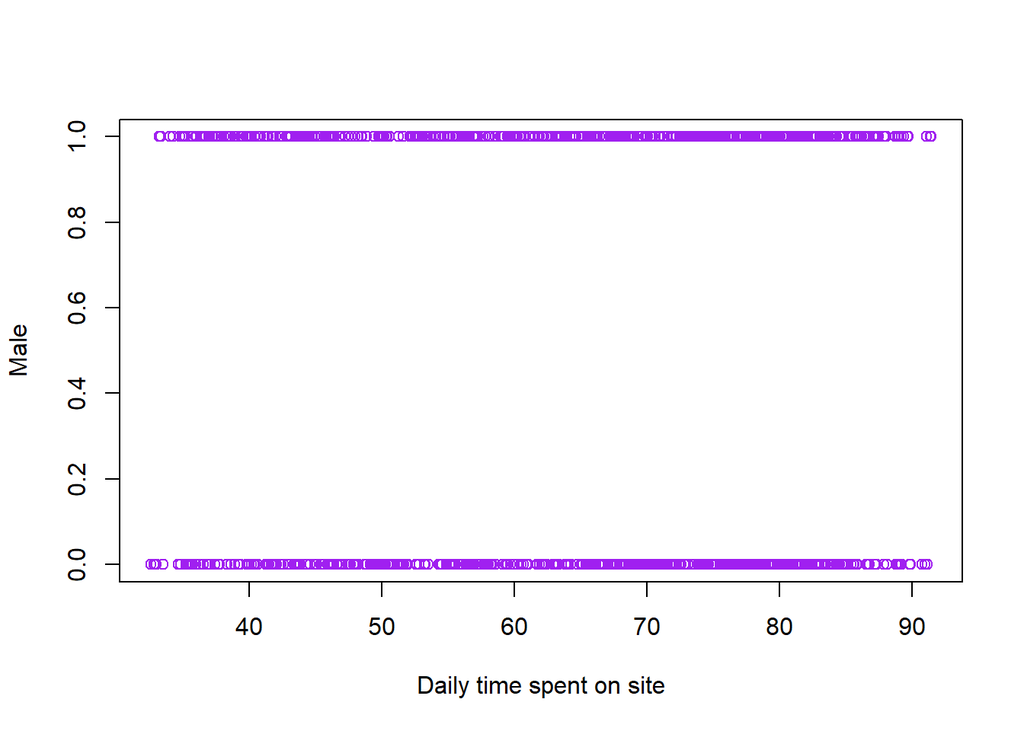

```r
plot(site, male,  xlab="Daily time spent on site", ylab="Male", col = "purple")
```